# ¶ *“S7 Investigación sobre la percepción de la 3° dosis”* ¶

[figure not shown]

## Título del proyecto

**Percepciones respecto a la aplicación de la tercera dosis contra el Covid como medio de salud y regreso a la normalidad**

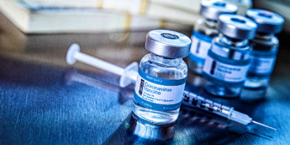

## I. Introducción

En los últimos años, la normalidad del planeta entero, entro en un cambio, a causa del Covid. La forma de vivir y cuidarse tomo un rumbo más precavido a causa del virus porque su nivel de contagio y mortalidad afecto en todos los niveles de vida conocidos. Es así que la normalidad tanto a nivel social, salud, transporte, etc. cambiaron para prevenir los focos de contagio, es así que las vacunas se volvieron un recurso importante para combatir este virus y así regresar a la normalidad. En estos términos, regresar a la normalidad tiene como requisito estar inmunizado contra el virus porque si no te encuentras vacunado no puedes regresar a tus actividades habituales; por lo que estarías dando lugar a más contagios eh incluso vulnerando tu salud y vida. En estas instancias se disponen de restricciones para el retorno a la vida cotidiana y si no se cumplen no eres apto para la nueva normalidad.

### 1.1 Importancia

El tema es importante porque, es un suceso actual y aún presente en el país; por lo consiguiente es importante indagar cuál es la percepción de las personas con respecto a las restricciones o condiciones necesarias para regresar a la normalidad social dentro de nuestro país.

### 1.2 Objetivos

Analizar el perfil promedio de las personas, para que, de tal forma, se comprenda cómo afecta este tipo de restricciones a las personas involucradas. Esto incluye tanto a las que son estudiantes, profesionales o no, como principales afectados, es así que es importante conocer sus percepciones con respecto las dosis contra el Covid y las restricciones que trae si no se aplican las dosis.

**Objetivos Específicos**

- *Determinar relaciones o patrones sobre los encuestados.*
- *Analizar las condiciones, percepciones, estímulos y efectos con respecto a la tercera dosis contra el Covid.*
- *Determinar si las personas están de acuerdo o no con respecto a las restricciones.*

### 1.3 Planificación

- *Para realizar este proyecto elaboramos un diagrama de Gantt, esto para que se pueda apreciar de una mejor forma nuestras actividades con el tiempo que nos tomó para su elaboración, este gráfico se hizo con la herramienta Canva*

[figure not shown]

## II. Datos

### 2.1 Recolección de datos:

- Se realizará por medio de encuestas y preguntas en su mayoría del tipo cerradas. La encuesta se hizo en la plataforma de Google, luego se dispuso a enviar el enlace de la encuesta a todos las personas para que así llegaran a responder según el marco de preguntas que se les indicó. Se optó las encuestas porque es un medio accesible de conseguir para no indagar en una base de datos ya preestablecidos; por lo tanto, se eligió las encuestas para una retroalimentación más directa; no obstante, es algo lenta.

### 2.3 Variables:

#### A) Variables Categóricas

| Descripción | Variable | Tipo de Variable | Restricciones |
| --- | --- | --- | --- |
| Sexo | Sexo | Categórica Nominal | Hombre y Mujer |
| Actualmente eres | Ocupación | Categórica nominal | 4 opciones |
| ¿En qué distrito te vacunaste?. Según el mapa | Lugar de vacunación | Categórica nominal | Todo Perú |
| ¿Cuál fue la vacuna que recibiste? | Tipo de vacuna | Categórica nominal | 3 Tipos |
| ¿Para ti es importante la 3° dosis? | Importancia | Categórica nominal | Si y No |
| ¿Consideras que es seguro aplicarse una tercera dosis de la vacuna? | Seguridad de la dosis | Categórica nominal | Si y No |
| ¿Es necesario que impidan la entrada a ciertos lugares por no tener la 3° dosis? | Impedimento | Categórica nominal | Si y No |

#### B) Variables numéricas

[output not shown]

### 2.4 Limpieza de base de datos:

**- Librerías a usar para la lectura de la data**

```r
library(readr)
library(dplyr)
library(modeest)
library(foreign)
library(fitdistrplus)
```

```r
library(ggplot2)
```

**- Lectura de la data**

```r
DF <- read.csv("datos.csv")
```

**- Renombramiento de las variables**

```r
DF %>% rename(Edad = Edad, Sexo = Sexo, Nivel_de_malestar = Cuanto.malestar.sentiste.luego.de.la.tercera.dosis.contra.el.Covid..Donde.0.es.una.escala.de.malestar.minimo.o.nada.y.10.una.escala.de.malestar.maximo., Tipo_de_vacuna = Cual.fue.la.vacuna.que.recibiste, Lugar_de_vacunacion = En.que.distrito.te.vacunaste, Dias_de_malestar = Cuantos.dias.de.malestar.sentiste, Importancia = Para.ti.es.importante.la.3.dosis, Seguridad_de_la_dosis = Consideras.que.es.seguro.aplicarse.una.tercera.dosis.de.la.vacuna, Impedimento = Es.necesario.que.impidan.la.entrada.a.ciertos.lugares.por.no.tener.la.3.dosis, Satisfaccion = Que.tan.satisfecho.te.encuentras.con.las.medidas.tomadas.por.el.gobierno.respecto.al.impedimento.de.ingreso.a.centros.comerciales.u.otros.locales., Peso= Pesoenkilogramos, Altura = Alturaencentimetros, dolorBrazo=tiemposentistedolorenelbrazohoras) -> DFN
```

**- Dimensiones de la data (Observaciones y variables)**

```r
dim(DFN)
```

```
## [1] 353  14
```

**- Recodificación de los tipo de variables**

```r
DFN$Altura[DFN$Altura == 1.6]<- 160
DFN$Peso[DFN$Peso <= 48]<- NA
DFN$dolorBrazo[DFN$dolorBrazo >= 150]<- NA
```